# Caso práctico final: Python

## Ejercicio 1.

Sobre los informes de felicidad de 2015 y 2016, realizar las siguientes exploraciones:

- Cargar los dos CSV como datasets.
- Identificra las columnas de ambos datasets: ¿hay diferencias entre ambos?
- Une ambos dataframes, sin importar que los dos compartan las mismas diferencias.
- Revisa el número de nulos que hay por cada columna, así como su porcentaje
- Cambia los valores nulos de las columnas "Lower Confidence Interval" y "Upper Confidence Interval" por un número aleatorio entre el valor mínimo y máximo de la misma columna (un único número, no es necesario uno diferente para cada fila con valor nulo).
- Cambia los valores nulos de la columna "Standard Error" por su media al cuadrado.
- Obtén un resumen estadístico del dataframe sin valores nulos.
- Muestra de forma gráfica la relación entre la familia y la salud.
- Muestra de forma gráfica la relación entre la puntuación de felicidad y la confianza (corrupción del gobierno).

```python
import csv
f2015 = open('2015.csv', mode='rt')
f2016= open('2016.csv', mode='rt')
```

```python
import pandas as pd
f2015=pd.read_csv('2015.csv')
f2016=pd.read_csv('2016.csv')
```

```python
f2015
```

|  | Country | Region | Happiness Rank | Happiness Score | Standard Error | Economy (GDP per Capita) | Family | Health (Life Expectancy) | Freedom | Trust (Government Corruption) | Generosity | Dystopia Residual |
| --- | --- | --- | --- | --- | --- | --- | --- | --- | --- | --- | --- | --- |
| 0 | Switzerland | Western Europe | 1 | 7.587 | 0.03411 | 1.39651 | 1.34951 | 0.94143 | 0.66557 | 0.41978 | 0.29678 | 2.51738 |
| 1 | Iceland | Western Europe | 2 | 7.561 | 0.04884 | 1.30232 | 1.40223 | 0.94784 | 0.62877 | 0.14145 | 0.43630 | 2.70201 |
| 2 | Denmark | Western Europe | 3 | 7.527 | 0.03328 | 1.32548 | 1.36058 | 0.87464 | 0.64938 | 0.48357 | 0.34139 | 2.49204 |
| 3 | Norway | Western Europe | 4 | 7.522 | 0.03880 | 1.45900 | 1.33095 | 0.88521 | 0.66973 | 0.36503 | 0.34699 | 2.46531 |
| 4 | Canada | North America | 5 | 7.427 | 0.03553 | 1.32629 | 1.32261 | 0.90563 | 0.63297 | 0.32957 | 0.45811 | 2.45176 |
| ... | ... | ... | ... | ... | ... | ... | ... | ... | ... | ... | ... | ... |
| 153 | Rwanda | Sub-Saharan Africa | 154 | 3.465 | 0.03464 | 0.22208 | 0.77370 | 0.42864 | 0.59201 | 0.55191 | 0.22628 | 0.67042 |
| 154 | Benin | Sub-Saharan Africa | 155 | 3.340 | 0.03656 | 0.28665 | 0.35386 | 0.31910 | 0.48450 | 0.08010 | 0.18260 | 1.63328 |
| 155 | Syria | Middle East and Northern Africa | 156 | 3.006 | 0.05015 | 0.66320 | 0.47489 | 0.72193 | 0.15684 | 0.18906 | 0.47179 | 0.32858 |
| 156 | Burundi | Sub-Saharan Africa | 157 | 2.905 | 0.08658 | 0.01530 | 0.41587 | 0.22396 | 0.11850 | 0.10062 | 0.19727 | 1.83302 |
| 157 | Togo | Sub-Saharan Africa | 158 | 2.839 | 0.06727 | 0.20868 | 0.13995 | 0.28443 | 0.36453 | 0.10731 | 0.16681 | 1.56726 |

158 rows × 12 columns

```python
f2016

#Se observan diferencias entre las columnas, el conjunto de 2016 presenta 2 columnas nuevas (Lower confidence interval and upper confidence interval) y no presenta la columna del error estandar que se observa en el dataset de 2015.
```

|  | Country | Region | Happiness Rank | Happiness Score | Lower Confidence Interval | Upper Confidence Interval | Economy (GDP per Capita) | Family | Health (Life Expectancy) | Freedom | Trust (Government Corruption) | Generosity | Dystopia Residual |
| --- | --- | --- | --- | --- | --- | --- | --- | --- | --- | --- | --- | --- | --- |
| 0 | Denmark | Western Europe | 1 | 7.526 | 7.460 | 7.592 | 1.44178 | 1.16374 | 0.79504 | 0.57941 | 0.44453 | 0.36171 | 2.73939 |
| 1 | Switzerland | Western Europe | 2 | 7.509 | 7.428 | 7.590 | 1.52733 | 1.14524 | 0.86303 | 0.58557 | 0.41203 | 0.28083 | 2.69463 |
| 2 | Iceland | Western Europe | 3 | 7.501 | 7.333 | 7.669 | 1.42666 | 1.18326 | 0.86733 | 0.56624 | 0.14975 | 0.47678 | 2.83137 |
| 3 | Norway | Western Europe | 4 | 7.498 | 7.421 | 7.575 | 1.57744 | 1.12690 | 0.79579 | 0.59609 | 0.35776 | 0.37895 | 2.66465 |
| 4 | Finland | Western Europe | 5 | 7.413 | 7.351 | 7.475 | 1.40598 | 1.13464 | 0.81091 | 0.57104 | 0.41004 | 0.25492 | 2.82596 |
| ... | ... | ... | ... | ... | ... | ... | ... | ... | ... | ... | ... | ... | ... |
| 152 | Benin | Sub-Saharan Africa | 153 | 3.484 | 3.404 | 3.564 | 0.39499 | 0.10419 | 0.21028 | 0.39747 | 0.06681 | 0.20180 | 2.10812 |
| 153 | Afghanistan | Southern Asia | 154 | 3.360 | 3.288 | 3.432 | 0.38227 | 0.11037 | 0.17344 | 0.16430 | 0.07112 | 0.31268 | 2.14558 |
| 154 | Togo | Sub-Saharan Africa | 155 | 3.303 | 3.192 | 3.414 | 0.28123 | 0.00000 | 0.24811 | 0.34678 | 0.11587 | 0.17517 | 2.13540 |
| 155 | Syria | Middle East and Northern Africa | 156 | 3.069 | 2.936 | 3.202 | 0.74719 | 0.14866 | 0.62994 | 0.06912 | 0.17233 | 0.48397 | 0.81789 |
| 156 | Burundi | Sub-Saharan Africa | 157 | 2.905 | 2.732 | 3.078 | 0.06831 | 0.23442 | 0.15747 | 0.04320 | 0.09419 | 0.20290 | 2.10404 |

157 rows × 13 columns

```python
data = pd.concat([f2015, f2016], axis=0)
```

```python
data
```

|  | Country | Region | Happiness Rank | Happiness Score | Standard Error | Economy (GDP per Capita) | Family | Health (Life Expectancy) | Freedom | Trust (Government Corruption) | Generosity | Dystopia Residual | Lower Confidence Interval | Upper Confidence Interval |
| --- | --- | --- | --- | --- | --- | --- | --- | --- | --- | --- | --- | --- | --- | --- |
| 0 | Switzerland | Western Europe | 1 | 7.587 | 0.03411 | 1.39651 | 1.34951 | 0.94143 | 0.66557 | 0.41978 | 0.29678 | 2.51738 | NaN | NaN |
| 1 | Iceland | Western Europe | 2 | 7.561 | 0.04884 | 1.30232 | 1.40223 | 0.94784 | 0.62877 | 0.14145 | 0.43630 | 2.70201 | NaN | NaN |
| 2 | Denmark | Western Europe | 3 | 7.527 | 0.03328 | 1.32548 | 1.36058 | 0.87464 | 0.64938 | 0.48357 | 0.34139 | 2.49204 | NaN | NaN |
| 3 | Norway | Western Europe | 4 | 7.522 | 0.03880 | 1.45900 | 1.33095 | 0.88521 | 0.66973 | 0.36503 | 0.34699 | 2.46531 | NaN | NaN |
| 4 | Canada | North America | 5 | 7.427 | 0.03553 | 1.32629 | 1.32261 | 0.90563 | 0.63297 | 0.32957 | 0.45811 | 2.45176 | NaN | NaN |
| ... | ... | ... | ... | ... | ... | ... | ... | ... | ... | ... | ... | ... | ... | ... |
| 152 | Benin | Sub-Saharan Africa | 153 | 3.484 | NaN | 0.39499 | 0.10419 | 0.21028 | 0.39747 | 0.06681 | 0.20180 | 2.10812 | 3.404 | 3.564 |
| 153 | Afghanistan | Southern Asia | 154 | 3.360 | NaN | 0.38227 | 0.11037 | 0.17344 | 0.16430 | 0.07112 | 0.31268 | 2.14558 | 3.288 | 3.432 |
| 154 | Togo | Sub-Saharan Africa | 155 | 3.303 | NaN | 0.28123 | 0.00000 | 0.24811 | 0.34678 | 0.11587 | 0.17517 | 2.13540 | 3.192 | 3.414 |
| 155 | Syria | Middle East and Northern Africa | 156 | 3.069 | NaN | 0.74719 | 0.14866 | 0.62994 | 0.06912 | 0.17233 | 0.48397 | 0.81789 | 2.936 | 3.202 |
| 156 | Burundi | Sub-Saharan Africa | 157 | 2.905 | NaN | 0.06831 | 0.23442 | 0.15747 | 0.04320 | 0.09419 | 0.20290 | 2.10404 | 2.732 | 3.078 |

315 rows × 14 columns

```python
print("*CANTIDAD de datos nulos por columna en el dataframe")
print(data.isnull().sum())
print("----------------------------------")
print("*PORCENTAJE de datos nulos por columna en el dataframe")
print(data.isnull().sum()/len(data)*100)
```

```
*CANTIDAD de datos nulos por columna en el dataframe
Country                            0
Region                             0
Happiness Rank                     0
Happiness Score                    0
Standard Error                   157
Economy (GDP per Capita)           0
Family                             0
Health (Life Expectancy)           0
Freedom                            0
Trust (Government Corruption)      0
Generosity                         0
Dystopia Residual                  0
Lower Confidence Interval        158
Upper Confidence Interval        158
dtype: int64
----------------------------------
*PORCENTAJE de datos nulos por columna en el dataframe
Country                           0.00000
Region                            0.00000
Happiness Rank                    0.00000
Happiness Score                   0.00000
Standard Error                   49.84127
Economy (GDP per Capita)          0.00000
Family                            0.00000
Health (Life Expectancy)          0.00000
Freedom                           0.00000
Trust (Government Corruption)     0.00000
Generosity                        0.00000
Dystopia Residual                 0.00000
Lower Confidence Interval        50.15873
Upper Confidence Interval        50.15873
dtype: float64
```

Cambia los valores nulos de las columnas "Lower Confidence Interval" y "Upper Confidence Interval" por un número aleatorio entre el valor mínimo y máximo de la misma columna (un único número, no es necesario uno diferente para cada fila con valor nulo).

```python
# Calculamos máximo de Lower Confidence Interval
print(data.iloc[:, 12].max())
# minimo
print(data.iloc[:,12].min())
```

```
7.46
2.732
```

```python
# Calculamos máximo deUpper Confidence Interval
print(data.iloc[:, 13].max())
# minimo
print(data.iloc[:,13].min())
```

```
7.669
3.078
```

```python
# Seleccionamos numero aleatorio entre ambos
import random
random_lower = random.uniform(2.732, 7.460)
print(random_lower)
random_upper = random.uniform(3.078, 7.669)
print(random_upper)
```

```
4.705216557275293
3.897620263171768
```

```python
#Cambiamos nan por valor aleatorio
data['Lower Confidence Interval'] = data['Lower Confidence Interval'].fillna(random_lower)
data['Upper Confidence Interval'] = data['Upper Confidence Interval'].fillna(random_upper)
```

```python
data.head(5)
```

|  | Country | Region | Happiness Rank | Happiness Score | Standard Error | Economy (GDP per Capita) | Family | Health (Life Expectancy) | Freedom | Trust (Government Corruption) | Generosity | Dystopia Residual | Lower Confidence Interval | Upper Confidence Interval |
| --- | --- | --- | --- | --- | --- | --- | --- | --- | --- | --- | --- | --- | --- | --- |
| 0 | Switzerland | Western Europe | 1 | 7.587 | 0.03411 | 1.39651 | 1.34951 | 0.94143 | 0.66557 | 0.41978 | 0.29678 | 2.51738 | 4.705217 | 3.89762 |
| 1 | Iceland | Western Europe | 2 | 7.561 | 0.04884 | 1.30232 | 1.40223 | 0.94784 | 0.62877 | 0.14145 | 0.43630 | 2.70201 | 4.705217 | 3.89762 |
| 2 | Denmark | Western Europe | 3 | 7.527 | 0.03328 | 1.32548 | 1.36058 | 0.87464 | 0.64938 | 0.48357 | 0.34139 | 2.49204 | 4.705217 | 3.89762 |
| 3 | Norway | Western Europe | 4 | 7.522 | 0.03880 | 1.45900 | 1.33095 | 0.88521 | 0.66973 | 0.36503 | 0.34699 | 2.46531 | 4.705217 | 3.89762 |
| 4 | Canada | North America | 5 | 7.427 | 0.03553 | 1.32629 | 1.32261 | 0.90563 | 0.63297 | 0.32957 | 0.45811 | 2.45176 | 4.705217 | 3.89762 |

Cambia los valores nulos de la columna "Standard Error" por su media al cuadrado.

```python
#primero obtenemos media al cuadrado de la varibale (omitiendo nan para cálculo)
sd_nonan=data['Standard Error'].dropna()
mean2_sd=sd_nonan.mean()**2
print(mean2_sd)
```

```
0.002292948979494474
```

```python
data['Standard Error'] = data['Standard Error'].fillna(mean2_sd)
data
```

|  | Country | Region | Happiness Rank | Happiness Score | Standard Error | Economy (GDP per Capita) | Family | Health (Life Expectancy) | Freedom | Trust (Government Corruption) | Generosity | Dystopia Residual | Lower Confidence Interval | Upper Confidence Interval |
| --- | --- | --- | --- | --- | --- | --- | --- | --- | --- | --- | --- | --- | --- | --- |
| 0 | Switzerland | Western Europe | 1 | 7.587 | 0.034110 | 1.39651 | 1.34951 | 0.94143 | 0.66557 | 0.41978 | 0.29678 | 2.51738 | 4.705217 | 3.89762 |
| 1 | Iceland | Western Europe | 2 | 7.561 | 0.048840 | 1.30232 | 1.40223 | 0.94784 | 0.62877 | 0.14145 | 0.43630 | 2.70201 | 4.705217 | 3.89762 |
| 2 | Denmark | Western Europe | 3 | 7.527 | 0.033280 | 1.32548 | 1.36058 | 0.87464 | 0.64938 | 0.48357 | 0.34139 | 2.49204 | 4.705217 | 3.89762 |
| 3 | Norway | Western Europe | 4 | 7.522 | 0.038800 | 1.45900 | 1.33095 | 0.88521 | 0.66973 | 0.36503 | 0.34699 | 2.46531 | 4.705217 | 3.89762 |
| 4 | Canada | North America | 5 | 7.427 | 0.035530 | 1.32629 | 1.32261 | 0.90563 | 0.63297 | 0.32957 | 0.45811 | 2.45176 | 4.705217 | 3.89762 |
| ... | ... | ... | ... | ... | ... | ... | ... | ... | ... | ... | ... | ... | ... | ... |
| 152 | Benin | Sub-Saharan Africa | 153 | 3.484 | 0.002293 | 0.39499 | 0.10419 | 0.21028 | 0.39747 | 0.06681 | 0.20180 | 2.10812 | 3.404000 | 3.56400 |
| 153 | Afghanistan | Southern Asia | 154 | 3.360 | 0.002293 | 0.38227 | 0.11037 | 0.17344 | 0.16430 | 0.07112 | 0.31268 | 2.14558 | 3.288000 | 3.43200 |
| 154 | Togo | Sub-Saharan Africa | 155 | 3.303 | 0.002293 | 0.28123 | 0.00000 | 0.24811 | 0.34678 | 0.11587 | 0.17517 | 2.13540 | 3.192000 | 3.41400 |
| 155 | Syria | Middle East and Northern Africa | 156 | 3.069 | 0.002293 | 0.74719 | 0.14866 | 0.62994 | 0.06912 | 0.17233 | 0.48397 | 0.81789 | 2.936000 | 3.20200 |
| 156 | Burundi | Sub-Saharan Africa | 157 | 2.905 | 0.002293 | 0.06831 | 0.23442 | 0.15747 | 0.04320 | 0.09419 | 0.20290 | 2.10404 | 2.732000 | 3.07800 |

315 rows × 14 columns

```python
print("*CANTIDAD de datos nulos por columna en el dataframe")
print(data.isnull().sum())
```

```
*CANTIDAD de datos nulos por columna en el dataframe
Country                          0
Region                           0
Happiness Rank                   0
Happiness Score                  0
Standard Error                   0
Economy (GDP per Capita)         0
Family                           0
Health (Life Expectancy)         0
Freedom                          0
Trust (Government Corruption)    0
Generosity                       0
Dystopia Residual                0
Lower Confidence Interval        0
Upper Confidence Interval        0
dtype: int64
```

```python
data.describe()
```

|  | Happiness Rank | Happiness Score | Standard Error | Economy (GDP per Capita) | Family | Health (Life Expectancy) | Freedom | Trust (Government Corruption) | Generosity | Dystopia Residual | Lower Confidence Interval | Upper Confidence Interval |
| --- | --- | --- | --- | --- | --- | --- | --- | --- | --- | --- | --- | --- |
| count | 315.000000 | 315.000000 | 315.000000 | 315.000000 | 315.000000 | 315.000000 | 315.000000 | 315.000000 | 315.000000 | 315.000000 | 315.000000 | 315.000000 |
| mean | 79.238095 | 5.378949 | 0.025161 | 0.899837 | 0.892647 | 0.594054 | 0.399896 | 0.140532 | 0.239957 | 2.212032 | 4.992890 | 4.687283 |
| std | 45.538922 | 1.141531 | 0.025851 | 0.410780 | 0.286718 | 0.240790 | 0.150684 | 0.115490 | 0.130077 | 0.558728 | 0.859274 | 1.127489 |
| min | 1.000000 | 2.839000 | 0.002293 | 0.000000 | 0.000000 | 0.000000 | 0.000000 | 0.000000 | 0.000000 | 0.328580 | 2.732000 | 3.078000 |
| 25% | 40.000000 | 4.510000 | 0.002293 | 0.594900 | 0.739880 | 0.419645 | 0.295890 | 0.061315 | 0.151430 | 1.884135 | 4.705217 | 3.897620 |
| 50% | 79.000000 | 5.286000 | 0.018480 | 0.973060 | 0.937930 | 0.640450 | 0.413190 | 0.106130 | 0.218540 | 2.211260 | 4.705217 | 3.897620 |
| 75% | 118.500000 | 6.269000 | 0.043940 | 1.229000 | 1.087360 | 0.787640 | 0.516730 | 0.178610 | 0.311450 | 2.563470 | 5.231500 | 5.408500 |
| max | 158.000000 | 7.587000 | 0.136930 | 1.824270 | 1.402230 | 1.025250 | 0.669730 | 0.551910 | 0.819710 | 3.837720 | 7.460000 | 7.669000 |

Muestra de forma gráfica la relación entre la familia y la salud.

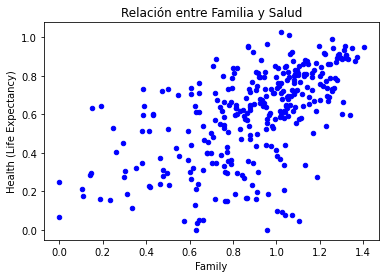

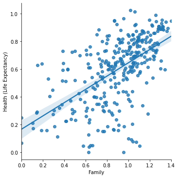

```python
import matplotlib.pyplot as plt
data.plot(kind='scatter', x='Family', color = "blue", y='Health (Life Expectancy)')
plt.title('Relación entre Familia y Salud')
import seaborn as sns
sns.lmplot(x="Family", y = 'Health (Life Expectancy)', data = data)
```

Muestra de forma gráfica la relación entre la puntuación de felicidad y la confianza (corrupción del gobierno).

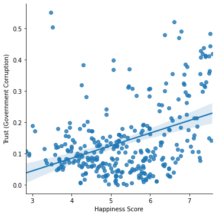

```python
sns.lmplot(x="Happiness Score", y = 'Trust (Government Corruption)', data = data)
```

Muestra la matriz de correlación del daframe.

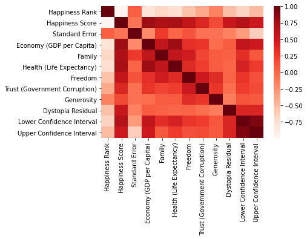

```python
sns.heatmap(data.corr(), cmap='Reds')
```

Tras unir los dataframes, los países aparecerán más de una vez. Muestra agrupado el dataframe por país con el valor máximo de felicidad, sin importar el año.

```python
data2=data
```

```python
data2.head()
```

|  | Country | Region | Happiness Rank | Happiness Score | Standard Error | Economy (GDP per Capita) | Family | Health (Life Expectancy) | Freedom | Trust (Government Corruption) | Generosity | Dystopia Residual | Lower Confidence Interval | Upper Confidence Interval |
| --- | --- | --- | --- | --- | --- | --- | --- | --- | --- | --- | --- | --- | --- | --- |
| 0 | Switzerland | Western Europe | 1 | 7.587 | 0.03411 | 1.39651 | 1.34951 | 0.94143 | 0.66557 | 0.41978 | 0.29678 | 2.51738 | 4.705217 | 3.89762 |
| 1 | Iceland | Western Europe | 2 | 7.561 | 0.04884 | 1.30232 | 1.40223 | 0.94784 | 0.62877 | 0.14145 | 0.43630 | 2.70201 | 4.705217 | 3.89762 |
| 2 | Denmark | Western Europe | 3 | 7.527 | 0.03328 | 1.32548 | 1.36058 | 0.87464 | 0.64938 | 0.48357 | 0.34139 | 2.49204 | 4.705217 | 3.89762 |
| 3 | Norway | Western Europe | 4 | 7.522 | 0.03880 | 1.45900 | 1.33095 | 0.88521 | 0.66973 | 0.36503 | 0.34699 | 2.46531 | 4.705217 | 3.89762 |
| 4 | Canada | North America | 5 | 7.427 | 0.03553 | 1.32629 | 1.32261 | 0.90563 | 0.63297 | 0.32957 | 0.45811 | 2.45176 | 4.705217 | 3.89762 |

```python
data2.groupby('Country').agg(max_Happiness = ('Happiness Score', lambda data: data.idxmax()))
```

| Country | max_Happiness |
| --- | --- |
| Afghanistan | 152.0 |
| Albania | 94.0 |
| Algeria | 37.0 |
| Angola | 136.0 |
| Argentina | 25.0 |
| ... | ... |
| Venezuela | 22.0 |
| Vietnam | 74.0 |
| Yemen | 135.0 |
| Zambia | 84.0 |
| Zimbabwe | 114.0 |

164 rows × 1 columns

¿Tiene relación la felicidad con la generosidad? Muéstralo gráficamente a través de la puntuación de libertad.

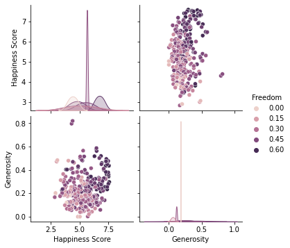

```python
import warnings

# Ignorar todos los warnings
warnings.filterwarnings("ignore")
sns.pairplot(data=data,vars=['Happiness Score','Generosity'], hue='Freedom')
#Parece observarse que los mayores valores de libertad se distribuyen mayormente en valores altos de felicidad coincidiendo con valores altos de generosidad. Así mismo se observa que la mayor parte de los valores más bajos de libertad (0.00-0.30), coinciden con valores medio-bajos de generosidad pero se dan casos de valores de felicidad altos casi de 6.4 aún así se observa que los que tienen menor puntuacion de libertad, son los menos generosos y los menos felices.
```

Muestra la distribución del grado de distopía en función de la región.

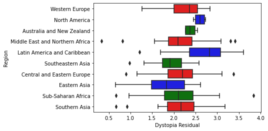

```python
sns.boxplot(x='Dystopia Residual',
            y='Region',
            data=data,
            palette=['red', 'blue', 'green'])
```